# ANN, SVM, & Complexity

## Artificial Neural Networks

In this section, we will build and test a multilayer perceptron.

**Exercise 1**. Read in the data file 'boomerang2D.txt' and split the dataset randomly into a training set and a test set of around equal size (hint: **train_test_split()** from **sklearn.model_selection**). Build a feed-forward neural network with two hidden layers consisting of 30 units each. You may use the method **MLPClassifier()** (module: **sklearn.neural_network**) as shown below. Predictions are done over the test set. Visualize the decision boundary of the neural network classifier.

```python
from sklearn.neural_network import MLPClassifier

#default activation is 'relu' for hidden layers.
model = MLPClassifier(solver='lbfgs', hidden_layer_sizes=(30,30), activation='logistic')
model.fit(X_train, y_train)

y_pred = model.predict(X_test)
y_pred_prob = model.predict_proba(X_test)

model.score(X_test, y_test) #accuracy
n_error = (y_pred!=y_test).sum()
```

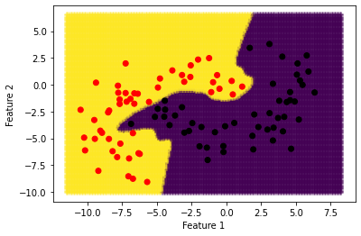

Finally, plot the ROC curve as measured on the test set and compute the area under the curve (AUC). You may use **roc_curve()** and **auc()** from **sklearn.metrics**.

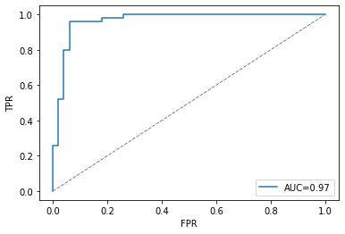

## Classifier Complexity

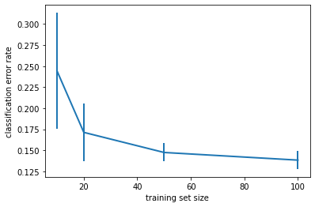

## Support Vector Machine

In this section, we will explore the support vector classifier using different kernel types.

**Exercise 3**. Using the same dataset as in the previous exercise, split this dataset in a stratified manner into a training set and a test set of equal size. A support vector classifier may be trained using **SVC()** (module: **sklearn.svm**), and testing may be carried out as usual using the method **predict()**. Use the line below to train the classifier.

```python
# model = SVC(kernel='linear', C=1, probability=True).fit(X_train, y_train)
```

Test the classifier on the test set and generate a confusion matrix with **confusion_matrix()** (from **sklearn.metrics)**. Here we have chosen a linear kernel. How much is the classification error? Change the kernel type to radial basis function `kernel='rbf'` with `C=1` and `gamma=1`; report the classification error. Finally, visualize the decision boundary of the classifier in the latter case (ie using an rbf kernel).

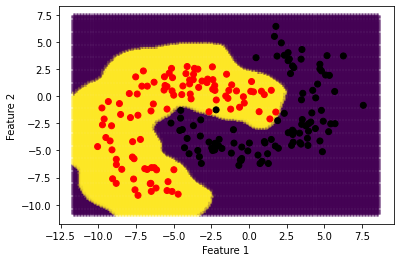

## Combining Classifiers

**Exercise 4**. Using the same dataset ('boomerang2Dlarge.txt'), randomly split this dataset equally into a training set and a test set in a stratified manner. Train a quadratic classifier and report the classification test error. Train a linear normal-based classifier and report the classification test error. In both cases also generate the class posterior probabilities using **predict_proba()** instead of **predict()**. This will return the posterior probabilities (ie confidence levels or soft labels) for every test object instead of a hard label. Combine the output of both classifiers using the product rule. Compare the (hard) labels returned by the product rule to each of the output (hard) labels of the quadratic and linear classifier. Are there any discrepancies?

## Support Vector Regression

In this section, we explore support vector regression.

**Exercise 5**. Use the provided function below to generate 50 noisy data points with $\sigma=0.1$ (standard deviation of the Gaussian noise added). Plot the resulting data points. Then train a support vector machine to perform regression with default parameters (hint: **SVR()** from module **sklearn.svm**) as shown below.

Then predict the response at the same data points using the trained model. Add the predicted points to the previous plot using a different color and marker. Finally, compute the root-mean-square-error (rmse) between the predicted values and the true values.

```python
# Below parameters are also default parameters

# from sklearn.svm import SVR
# model = SVR(kernel='rbf', C=1, epsilon=0.1, gamma='scale').fit(X_train.reshape(-1,1), y_train)
```

```python
def synth_data(n_samples, sigma):
    X = np.random.uniform(low=0, high=2, size=n_samples)
    X = np.sort(X)
    y = np.sin(4*X) + np.random.normal(loc=0, scale=sigma, size=n_samples)
    return X, y
```

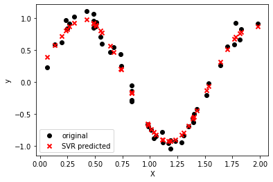

```python
from sklearn.model_selection import GridSearchCV

parameters = {'kernel' : ['rbf'],
              'gamma'  : np.linspace(1,10,20),
              'epsilon': np.linspace(0,1,10),
              'C'      : 2**np.arange(2,10)}

#neg_mean_squared_error is used because the method selects mode with max criterion by default
model = GridSearchCV(SVR(), parameters, scoring='neg_mean_squared_error', cv=5)
model.fit(X_train.reshape(-1,1), y_train)
model.best_params_

y_pred = model.predict(X_train.reshape(-1,1))
```

**Exercise 7**. Use the optimized model of the previous exercise to perform prediction that includes extrapolation, ie predict the response for the following input which extends beyond the range of the training set.

**X_test = np.arange(-1,3,0.05)**

In the same figure, plot the original training set along with the predicted values for this new input **X_test**.

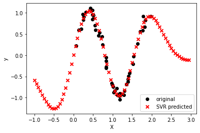